# Python

### 例3

- 想百度提交关键词，并返回结果

```python
import requests
```

```python
kv = {"wd": "Python"}
r = requests.get("https://www.baidu.com/s",params = kv)##获取百度的关键词的网址
r.status_code
```

```
200
```

```python
r.request.url
```

```
'https://wappass.baidu.com/static/captcha/tuxing.html?&ak=c27bbc89afca0463650ac9bde68ebe06&backurl=https%3A%2F%2Fwww.baidu.com%2Fs%3Fwd%3DPython&logid=9096681257001171234&signature=5c362f2b7b62a1f386eeabb5f26e5535&timestamp=1586937774'
```

```python
len(r.text)
```

```
1519
```

```python
import requests
kv = {"q": "Python"}
r = requests.get("https://www.so.com/s", params = kv)##获取百度的关键词的网址
r.status_code
```

```
200
```

```python
r.request.url
```

```
'https://www.so.com/s?q=Python'
```

### 例4 ：网络图片的爬取与存储

```python
import requests
url = "http://img0.dili360.com/ga/M02/02/18/wKgBzFQ2x9eAbZn8AATCSQolols997.jpg"
r = requests.get(url)
```

```python
r.status_code
```

```
200
```

```python
with open("exp5.jpg","wb") as f:
    f.write(r.content)
#返回的是图片的2进制编码
f.close
```

```
<function BufferedWriter.close>
```

- 全代码

```python
import requests
import os
url = "http://img0.dili360.com/ga/M02/02/18/wKgBzFQ2x9eAbZn8AATCSQolols997.jpg"
root = "D://Pics//"
path = root + url.split("/")[-1]
try:
    if not os.path.exists(root):
        os.mkdir(root)
    if not os.path.exists(path):
        r = requests.get(url)
        with open(path,"wb") as f:
            f.write(r.content)
            f.close()
            print("文件保存成功")
    else:
        print("文件已存在")
except:
    print("失败")
```

```
文件保存成功
```

```
(652, 2000, 3)
```

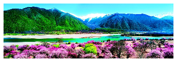

```python
import matplotlib.pyplot as plt
import matplotlib.image as mpimg
import numpy as np
cat = mpimg.imread('123.jpg')
print(cat.shape)
plt.imshow(cat)
plt.axis('off')
plt.show()
```

### 例5：IP地址归属地自动查询

```python
import requests
url = "https://www.ip138.com/iplookup.asp?ip="
try:
    r = requests.get(url+"202.204.80.112")
    r.raise_for_status()
    r.encoding = r.apparent_encoding
    print(r.text[-500:])
except:
    print("失败")
```

```
失败
```

## 使用 Beautiful soup 爬虫

```python
import requests
r = requests.get("http://python123.io/ws/demo.html")
r.text
```

```
'<html><head><title>This is a python demo page</title></head>\r\n<body>\r\n<p class="title"><b>The demo python introduces several python courses.</b></p>\r\n<p class="course">Python is a wonderful general-purpose programming language. You can learn Python from novice to professional by tracking the …
```

```python
demo = r.text
```

```python
from bs4 import BeautifulSoup
```

```python
soup = BeautifulSoup(demo, "html.parser")##html.parser是解析器
```

```python
print(soup.prettify())
```

```
<html>
 <head>
  <title>
   This is a python demo page
  </title>
 </head>
 <body>
  <p class="title">
   <b>
    The demo python introduces several python courses.
   </b>
  </p>
  <p class="course">
   Python is a wonderful general-purpose programming language. You can learn Python from novice to professional by tracking the following courses:
   <a class="py1" href="http://www.icourse163.org/course/BIT-268001" id="link1">
    Basic Python
   </a>
   and
   <a class="py2" href="http://www.icourse163.org/course/BIT-1001870001" id="link2">
    Advanced Python
   </a>
   .
  </p>
 </body>
</html>
```

- BeautifulSoup库是解析、遍历、维护“标签树”的功能库
- BeautifulSoup对应一个HTML/XML文档的全部内容

### BeautifulSou 的基本元素

- Tag: 标签，最基本的信息组织单元，分别应<>和</>标明开头和结尾；
- Name: 标签的名字, `<p>...<\p>` 的名字是"p",格式：`<tag>.name`；
- Attributes: 标签的属性，字典的形式组织，格式：`<tag>.attrs`；
- NavigableString: 标签内非属性字符串,`<>...</>`中字符串，格式：`<tag>.string`；
- Comment: 标签内字符串的注释部分，一张特殊的Comment类型；

```python
soup.title
```

```
<title>This is a python demo page</title>
```

```python
tag = soup.a#文本中有两个a标签，这个命令只能取出第一个
tag
```

```
<a class="py1" href="http://www.icourse163.org/course/BIT-268001" id="link1">Basic Python</a>
```

```python
soup.a.name
```

```
'a'
```

```python
soup.a.parent.name#a的父亲的标签
```

```
'p'
```

```python
soup.a.parent.parent.name#p标签父亲发标签
```

```
'body'
```

```python
tag.attrs#标签a的属性，，tag = soup.a，结果是一个字典
```

```
{'href': 'http://www.icourse163.org/course/BIT-268001',
 'class': ['py1'],
 'id': 'link1'}
```

```python
tag.attrs["href"]
```

```
'http://www.icourse163.org/course/BIT-268001'
```

```python
type(tag)
```

```
bs4.element.Tag
```

```python
soup.a.string
```

```
'Basic Python'
```

### 标签树的下行遍历

- .content： 子节点的列表，将所有儿子节点存入列表；
- .children 子节点的迭代类型，与.content类似，用于循环遍历儿子节点；
- .descendants 子孙节点的迭代类型，包含所有子孙节点，用于循环遍历；

```python
soup.head.contents
```

```
[<title>This is a python demo page</title>]
```

```python
soup.body.contents#是列表
```

```
['\n',
 <p class="title"><b>The demo python introduces several python courses.</b></p>,
 '\n',
 <p class="course">Python is a wonderful general-purpose programming language. You can learn Python from novice to professional by tracking the following courses:
 <a class="py1" href="http://www.icourse163.org/course/BIT-268001" id="link1">Basic Python</a> and <a class="py2" href="http://www.icourse163.org/course/BIT-1001870001" id="link2">Advanced Python</a>.</p>,
 '\n']
```

```python
len(soup.body.contents)
```

```
5
```

```python
soup.body.contents[1]
```

```
<p class="title"><b>The demo python introduces several python courses.</b></p>
```

- 遍历儿子节点

```python
for child in soup.body.children:
    print(child)
```

```
<p class="title"><b>The demo python introduces several python courses.</b></p>


<p class="course">Python is a wonderful general-purpose programming language. You can learn Python from novice to professional by tracking the following courses:
<a class="py1" href="http://www.icourse163.org/course/BIT-268001" id="link1">Basic Python</a> and <a class="py2" href="http://www.icourse163.org/course/BIT-1001870001" id="link2">Advanced Python</a>.</p>
```

- 遍历子孙节点

```python
for child in soup.body.descendants:
    print(child)
```

```
<p class="title"><b>The demo python introduces several python courses.</b></p>
<b>The demo python introduces several python courses.</b>
The demo python introduces several python courses.


<p class="course">Python is a wonderful general-purpose programming language. You can learn Python from novice to professional by tracking the following courses:
<a class="py1" href="http://www.icourse163.org/course/BIT-268001" id="link1">Basic Python</a> and <a class="py2" href="http://www.icourse163.org/course/BIT-1001870001" id="link2">Advanced Python</a>.</p>
Python is a wonderful general-purpose programming language. You can learn Python from novice to professional by tracking the following courses:

<a class="py1" href="http://www.icourse163.org/course/BIT-268001" id="link1">Basic Python</a>
Basic Python
 and
<a class="py2" href="http://www.icourse163.org/course/BIT-1001870001" id="link2">Advanced Python</a>
Advanced Python
.
```

### 标签树的上行遍历

- .parent： 节点的父亲标签；
- .parents 节点的先辈标签的迭代类型，用于循环遍历先辈节点；
- 标签树的上行遍历

```python
soup = BeautifulSoup(demo, "html.parser")
for parent in soup.a.parents:
    if parent is None:
        print(parent)
    else:
        print(parent.name)
```

```
p
body
html
[document]
```

### 标签树的平行遍历

- .next_sibling: 返回按照HTML文本顺序的下一个平行节点标签；
- .previous_sibling: 返回按照HTML文本顺序的上一个平行标签；
- .next_sibling: 迭代类型，返回按照HTML文本顺序的后续所有平行标签；
- .previous_sibling: 迭代类型，返回按照HTML文本顺序的前续所有平行标签；
- 所有平行标签发生在同一个父亲节点下的各节点间

```python
soup.a.next_sibling
```

```
' and '
```

```python
soup.a.next_sibling.next_sibling
```

```
<a class="py2" href="http://www.icourse163.org/course/BIT-1001870001" id="link2">Advanced Python</a>
```

```python
soup.a.previous_sibling
```

```
'Python is a wonderful general-purpose programming language. You can learn Python from novice to professional by tracking the following courses:\r\n'
```

- 遍历后续节点

```python
for each in soup.a.next_sibling:
    print(each)
```

```
a
n
d
```

- 遍历前续节点

```python
#for each in soup.a.previous_sibling:
#    print(each)
```

## 基于BeautifulSoup库的HTML格式输出

```python
print(soup.prettify())#prettify可以很好的把HTML打印出来
```

```
<html>
 <head>
  <title>
   This is a python demo page
  </title>
 </head>
 <body>
  <p class="title">
   <b>
    The demo python introduces several python courses.
   </b>
  </p>
  <p class="course">
   Python is a wonderful general-purpose programming language. You can learn Python from novice to professional by tracking the following courses:
   <a class="py1" href="http://www.icourse163.org/course/BIT-268001" id="link1">
    Basic Python
   </a>
   and
   <a class="py2" href="http://www.icourse163.org/course/BIT-1001870001" id="link2">
    Advanced Python
   </a>
   .
  </p>
 </body>
</html>
```

```python
soup1 = BeautifulSoup("<p>中文</p>", "html.parser")
print(soup1.prettify())
```

```
<p>
 中文
</p>
```

## 信息标记与提取

### 信息标记的三种形式：

- XML: 最早的通用信息标记语言，可扩展性好，但繁琐；
- JSON： 信息又类型，适合程序处理，较XML简洁；
- YAML： 信息无类型，文本信息比例较高，可读性较好；

### 信息提取的一般方法

- 完整解析信息的标记形式，再提取关键信息；
- 无视标记信息，直接搜素关键信息；
- 融合方法，即结合形式解析与搜索方法，提取关键信息（此方法教好）

#### 例如， 提取HTML所有url连接,

```python
from bs4 import BeautifulSoup
```

```python
for each in soup.find_all("a"):
    print(each.get("href"))
#提取soup中所有标签a的链接
```

```
http://www.icourse163.org/course/BIT-268001
http://www.icourse163.org/course/BIT-1001870001
```

##### find_all(name, attrs,recursive,string,***)的使用：返回一个列表类型，储存查找的结果。

- name:对标签名称的检索字符串；
- attrs: 对标签属性值检索的字符串，可标注属性检索；
- recursive： 是否对子孙全部检索，默认True；
- string: <>...</>中字符串区域的检索字符串；

```python
soup.find_all("a")
```

```
[<a class="py1" href="http://www.icourse163.org/course/BIT-268001" id="link1">Basic Python</a>,
 <a class="py2" href="http://www.icourse163.org/course/BIT-1001870001" id="link2">Advanced Python</a>]
```

```python
soup.find_all(["a","b"])
```

```
[<b>The demo python introduces several python courses.</b>,
 <a class="py1" href="http://www.icourse163.org/course/BIT-268001" id="link1">Basic Python</a>,
 <a class="py2" href="http://www.icourse163.org/course/BIT-1001870001" id="link2">Advanced Python</a>]
```

```python
import re
```

```python
for each in soup.find_all(re.compile("b")):
    print(each.name)
# 查找所有以b开头的标签
```

```
body
b
```

- `<tag>(..)`等价于`<tag>.find_all(..)`
- `soup(..)`等价于`soup.find_all(..)`

## 中国大学排名爬虫

```python
import requests
from bs4 import BeautifulSoup
import bs4
```

```python
def getHTMLText(url):
    try:
        r = requests.get(url)
        r.raise_for_status()
        r.encoding = r.apparent_encoding
        return r.text
    except:
        return ""
```

```python
def fillUniList(ulist,html):
    soup = BeautifulSoup(html, "html.parser")
    ## 因为所有信息都在tbody中，一个tr对于一所学校的信息，td是学校的具体信息
    for tr in soup.find("tbody").children:
        if isinstance(tr, bs4.element.Tag):
            tds = tr("td")
            ulist.append([tds[0].string,tds[1].string,tds[2].string,tds[3].string,tds[4].string])
```

```python
def printUniList(ulist,num):
    tplt = "{0:^6}\t{1:^10}\t{2:^6}\t{3:^6}\t{4:^6}"
    print(tplt.format("排名","学校名称","省市","总分","生源质量"))
    for i in range(num):
        u=ulist[i]
        print(tplt.format(u[0],u[1],u[2],u[3],u[4]))
```

```python
def main(num):
    unifo=[]
    url="http://www.zuihaodaxue.com/zuihaodaxuepaiming2019.html"
    html=getHTMLText(url)
    fillUniList(unifo,html)
    printUniList(unifo,num)
```

```python
main(30)#num  是学校个数
```

```
  排名  	   学校名称   	  省市  	  总分  	 生源质量
  1   	   清华大学   	  北京  	 94.6 	100.0
  2   	   北京大学   	  北京  	 76.5 	 95.2
  3   	   浙江大学   	  浙江  	 72.9 	 84.2
  4   	  上海交通大学  	  上海  	 72.1 	 91.1
  5   	   复旦大学   	  上海  	 65.6 	 91.6
  6   	 中国科学技术大学 	  安徽  	 60.9 	 91.1
  7   	  华中科技大学  	  湖北  	 58.9 	 80.1
  7   	   南京大学   	  江苏  	 58.9 	 86.2
  9   	   中山大学   	  广东  	 58.2 	 79.7
  10  	 哈尔滨工业大学  	 黑龙江  	 56.7 	 76.6
  11  	 北京航空航天大学 	  北京  	 56.3 	 86.9
  12  	   武汉大学   	  湖北  	 56.2 	 82.4
  13  	   同济大学   	  上海  	 55.7 	 85.2
  14  	  西安交通大学  	  陕西  	 55.0 	 82.0
```

[output cut: 16 more lines]

## 正则表达式（Regular Expression）

- 用来简洁表达一组字符串的表达式
- 正则表达式常用的操作符

[figure not shown]

- 例如

[figure not shown]

## re库的使用

#### re库主要功能函数

[figure not shown]

```python
import re
```

```python
match = re.search(r"[1-9]\d{5}","BIT 100081")
```

```python
match
```

```
<re.Match object; span=(4, 10), match='100081'>
```

```python
re.match(r"[1-9]\d{5}","BIT 100081")#group方法，因为被匹配的初始不是要匹配的，所以为空
```

```python
re.match(r"[1-9]\d{5}","100081 BIT")
```

```
<re.Match object; span=(0, 6), match='100081'>
```

```python
re.findall(r"[1-9]\d{5}","100081 BIT 100086")
```

```
['100081', '100086']
```

### RE库另一种等价表达方式

[figure not shown]

```python
m = re.search(r"[1-9]\d{5}","100081 BIT 100086")
m
```

```
<re.Match object; span=(0, 6), match='100081'>
```

```python
m.group(0)
```

```
'100081'
```

```python
m = re.search(r"PY.*N", "PYANBNCNDN")#贪婪匹配，即输入最长的满足正则表达式的字符串
m
```

```
<re.Match object; span=(0, 10), match='PYANBNCNDN'>
```

```python
m.group(0)
```

```
'PYANBNCNDN'
```

[figure not shown]

```python
m = re.search(r"PY.*?N", "PYANBNCNDN")#最小匹配，
```

```python
m.group(0)
```

```
'PYAN'
```

## 淘宝商品比价定向爬虫 失败

- 目标：获取淘宝搜素页面信息，提取其中商品的名称和价格；
- 理解：淘宝的搜素接口和翻页的处理；

```python
import requests
import re
```

```python
def getHTMLText(url):
    try:
        head = {"User-Agent": "Mozilla/5.0 (Windows NT 10.0; Win64; x64) AppleWebKit/537.36 (KHTML, like Gecko) Chrome/70.0.3538.102 Safari/537.36 Edge/18.18363"}
        r = requests.get(url, headers = head)
        r.raise_for_status()
        r.encoding = r.apparent_encoding
        return r.text
    except:
        return ""
```

```python
def parasePage(ilt,html):
    try:
        plt = re.findall(r'p-price=\"[\d\.]*\"',html)
        tlt = re.findall(r'p-name=\".*?\"',html)
        for i in range(len(plt)):
            price = eval(plt[i].split('=')[1])
            title = eval(tlt[i].split('=')[1])
            ilt.append([price,title])
    except:
        print("")
```

```python
def printGoodList(ilt):
    tplt = "{:4}\t{:8}\t{:16}"
    print(tplt.format("序号","价格","商品名称"))
    count = 0
    for g in ilt:
        count =count + 1
        print(tplt.format(count,g[0],g[1]))
```

```python
def main():
    Goods = "书包"
    depth = 1
    start_url = "https://s.taobao.com/search?q="+Goods
    infoList=[]
    for i in range(depth):
        try:
            url = start_url + "&s=" + str(44*i)#每个页面有44个商品, 第一页的数字是44，第二页的数字是88，等等,淘宝需要登录，所以我们用京东
            html = getHTMLText(url)
            parasePage(infoList,html)
        except:
            continue
    printGoodList(infoList)
```

```python
main()
```

```
序号  	价格      	商品名称
```

## Scrapy

### Scrapy爬虫框架结构

#### 爬虫框架

- 爬虫框架是实现爬虫功能的一个软件结构和功能组件集合；
- 爬虫框架是一个半成品，能够帮用户实现专业网络爬虫；

[figure not shown]

- 用户只需要编辑输入SPIDERS和输出ITEM PIPELINES,其他的scrapy已经编写好。

### Spiders 块的作用

- 解析DOWENLOADER返回的响应（response）
- 产生爬取项
- 产生额外的爬取请求

## Scrapy爬虫常用命令

[figure not shown]

### Scrapy 爬虫实例1

- 建立一个scrapy爬虫的工程：scrapy startproject python123#python123为文件名

  ```
   如果出错，可能是环境变量未配置好，需要添加 D:\ProgramData\Anaconda3\Scripts 和 D:\ProgramData\Anaconda3\Library\bin.
  ```

- 生成的文件说明

[figure not shown]

## 具体生成一个爬虫spider：scrapy genspider demo python123.io

## 配置所产生的spider

```python
import scrapy
class DemoSpider(scrapy.Spider):
    name = 'demo'
    start_urls = ['http://python123.io/ws/demo.html']

    def parse(self, response):
        fname = response.url.split("/")[-1]
        with open(fname,"wb") as f:
            f.write(response.body)
        self.log("Save file %s." % fname)
```

## 运行爬虫，获取网页:scrapy crawl demo

- 生成一个HTML文件